# Projeto - Red Wine

Vamos analisar a distribui????o alc??lica por nota. Assim poderemos ter uma ideia melhor de como est??o distribu??do os valores.

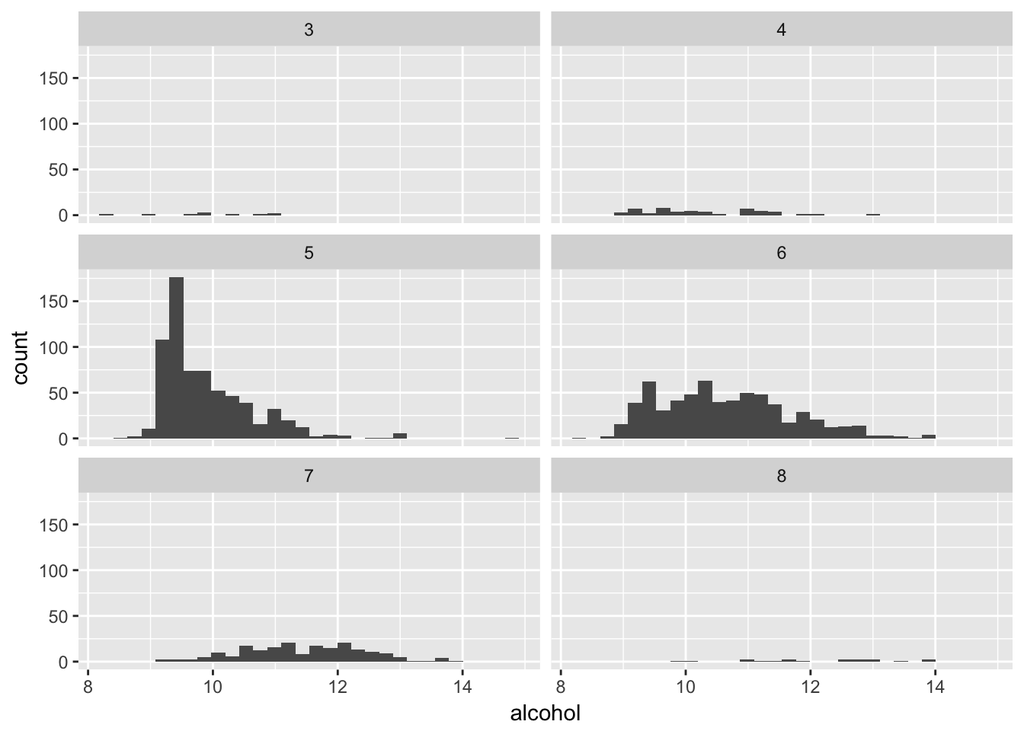

```r
ggplot(wines, mapping = aes(x = alcohol))+
  geom_histogram()+
  facet_wrap( ~ quality, ncol = 2)
```

O gr??fico acima torna meio dif??cil de visualizar os dados, pois a quantidade de vinhos com qualidade entre 5 e 6 ?? muito superior aos demais, e podemos observar que nenhuma das outras qualidades possuem valores suficientes para conseguirmos visualizar algum padr??o, n??o ao menos vendo os dados dessa perspectiva. Vou focar em valores de y de no m??ximo 50 unidades, somente para termos uma melhor visualiza????o das demais qualidades.

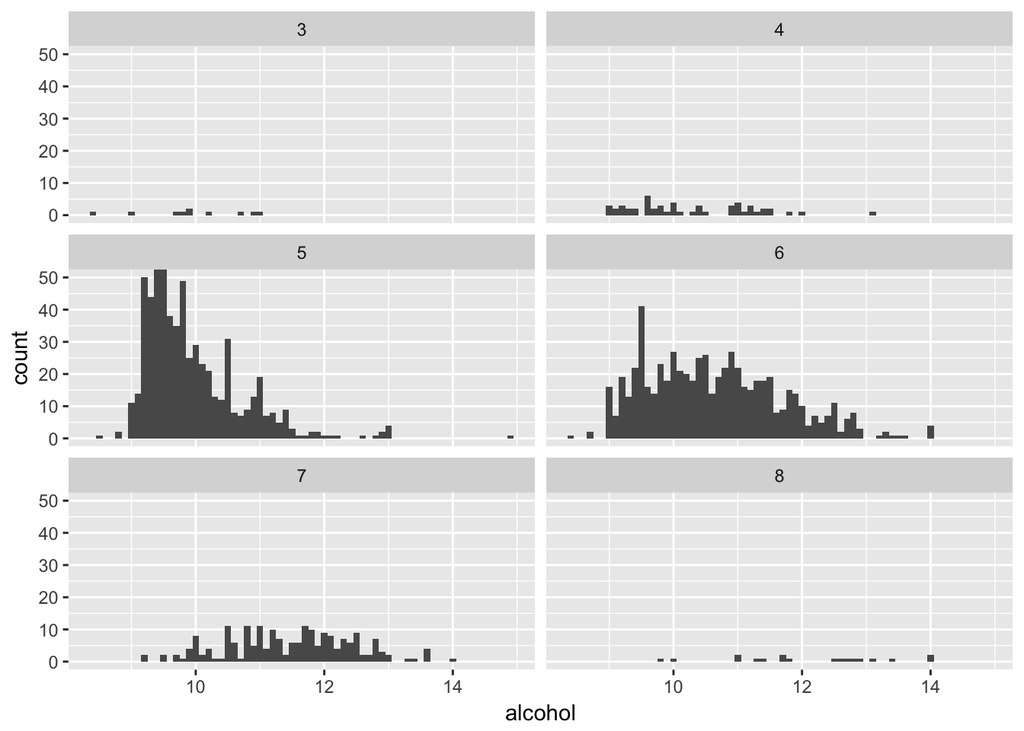

```r
ggplot(wines, mapping = aes(x = alcohol))+
  geom_histogram(binwidth = 0.1)+
  coord_cartesian(ylim = c(0, 50))+
  facet_wrap( ~ quality, ncol = 2)
```

Vamos mudar a abordagem, vamos criar um gr??fico de ??ndice alc??lico por qualidade usando n??o mais a quantitidade mas a densisdade dos dados.

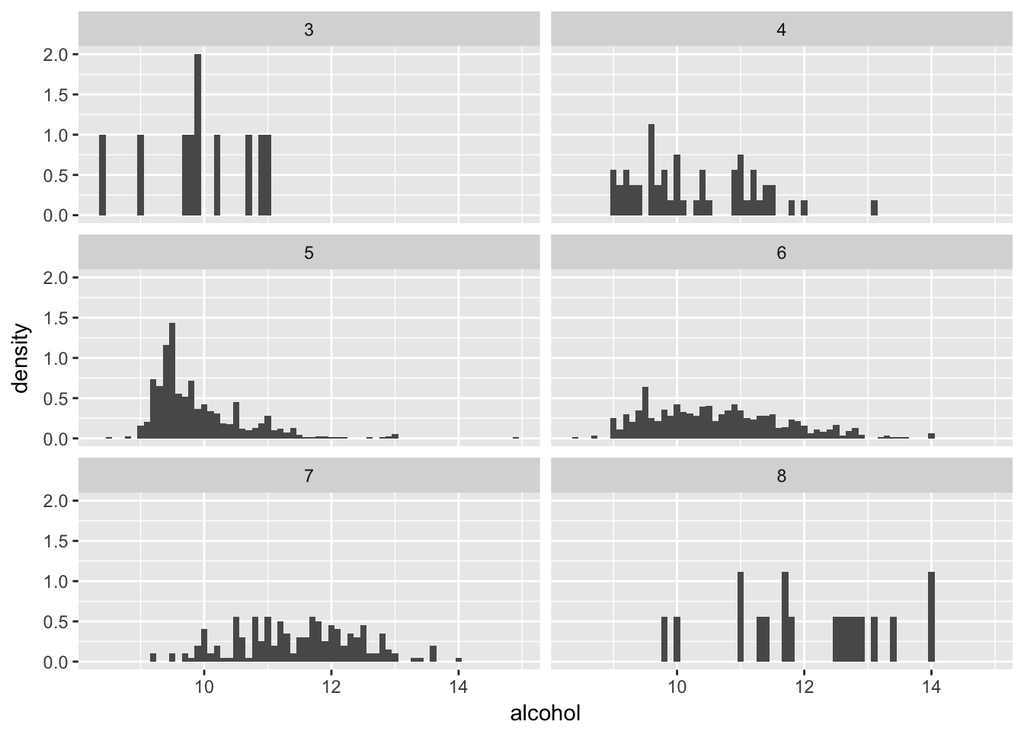

```r
ggplot(wines, mapping = aes(x = alcohol, y = ..density..))+
  geom_histogram(binwidth = 0.1)+
  facet_wrap( ~ quality, ncol = 2)
```

Agora sim, temos uma vis??o diferente dos dados. Esse gr??fico vai de encontro com o que foi levantado anteriormente: os vinhos com qualidades infeiores possuem sua concentra????o maior mais localizada a esquerda da distribu????o, vinhos com qualidade mais alta aparentam ter uma distribui????o mais a direita do gr??fico. Ainda assim ?? dif??cil levantar “bandeira” para sinalizar algo.

Vamos ent??o validar se os n??veis de a??ucar residual possuem algum papel nesse resultado.

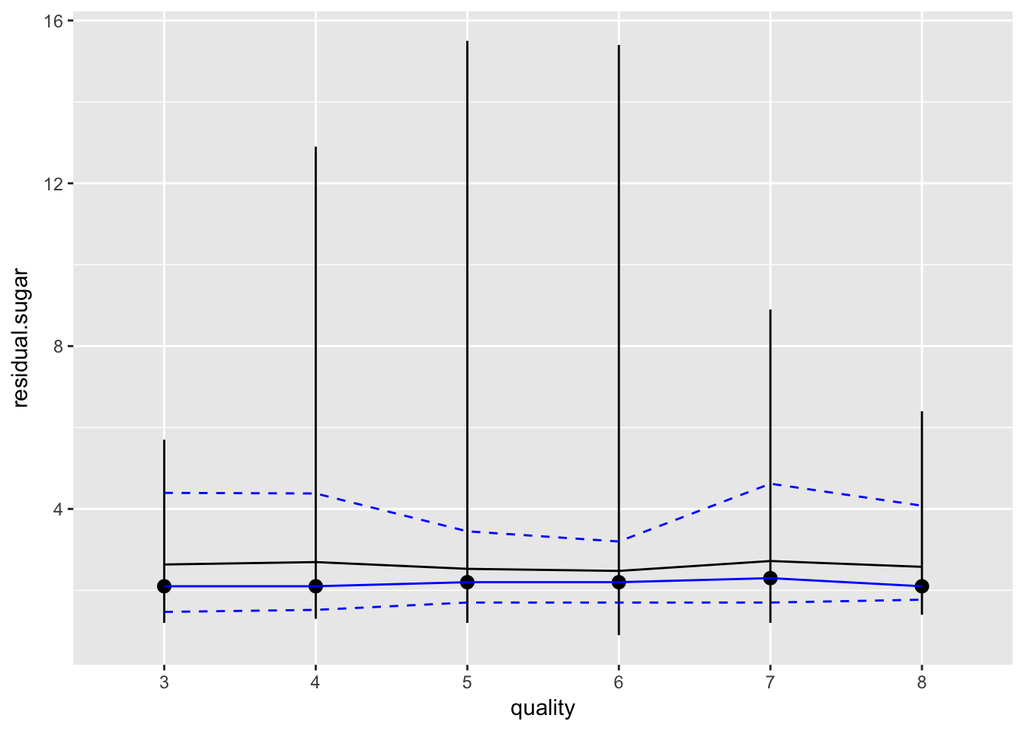

```r
ggplot(data = wines, mapping = aes(x = quality, y = residual.sugar, group = 1))+
  stat_summary(fun.ymin = min, fun.ymax = max, fun.y = median)+
  geom_line(stat = 'summary', fun.y = mean)+
  geom_line(stat = 'summary', fun.y = quantile, fun.args = list(probs = .1),
            linetype = 2, color =  'blue')+
  geom_line(stat = 'summary', fun.y = quantile, fun.args = list(probs = .5),
            color =  'blue')+
  geom_line(stat = 'summary', fun.y = quantile, fun.args = list(probs = .9),
            linetype = 2, color =  'blue')
```

Podemos descarta esta ideia, visto que temos uma m??dia de n??vel residual de a??ucar quase id??ntica para cada grupo de qualidade. Lendo e estudando sobre este mundo de vinhos, acabo me deparando com a seguinte constata????o feita em um blog especializado em vinho: “As much as modern health has demonized acidic foods, acidity is an essential trait in wine that???s necessary for quality. Great wines are in balance with their 4 fundamental traits (Acidity, tannin, alcohol and sweetness) and as wines age, the acidity acts as a buffer to preserve the wine longer. For example, Sauternes, a wine with both high acidity and sweetness, is known to age several decades.”

Bom, segundo o que foi dito, vinhos de mais alta qualidade possuem n??veis elevados de acidez. E nossa acidez ?? indicada pelo pH do vinho, segundo a pr??pria base de dados quanto mais pr??ximo de zero, mais ??cido ?? o vinho. As informa????es tamb??m indicam que um a maioria dos vinhos vai ter um pH entre 3 e 4.

[output not shown]

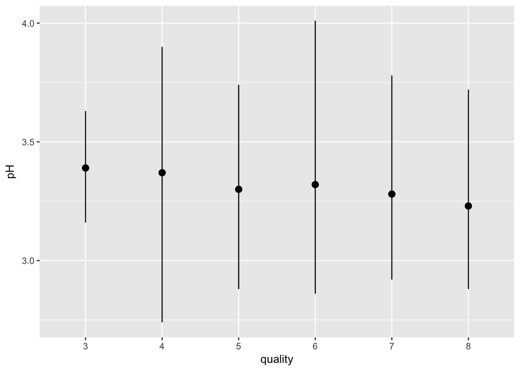

```r
ggplot(aes(x = quality, y = pH), data = wines)+
  stat_summary(fun.ymin = min, fun.ymax = max, fun.y = median)+
  geom_line(stat = 'summary', fun.y = mean)+
  geom_line(stat = 'summary', fun.y = quantile, fun.args = list(probs = .1),
            linetype = 2, color =  'blue')+
  geom_line(stat = 'summary', fun.y = quantile, fun.args = list(probs = .5),
            color =  'blue')+
  geom_line(stat = 'summary', fun.y = quantile, fun.args = list(probs = .9),
            linetype = 2, color =  'blue')
```

#### Vamos verificar como se da a distribui????o de pH e qualidade.

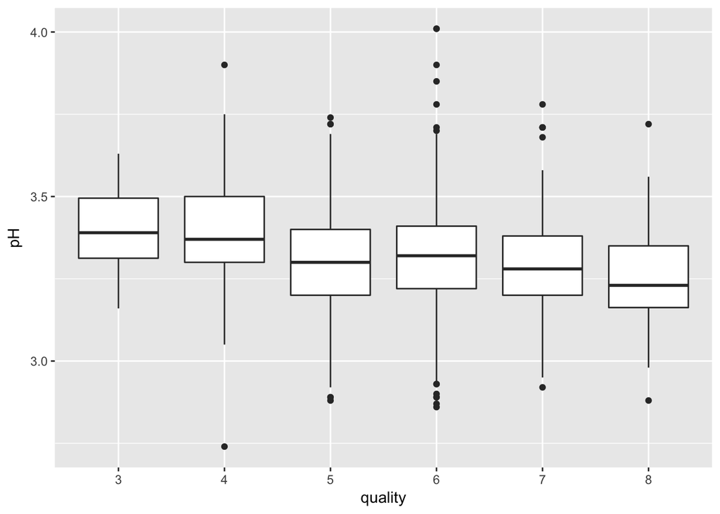

```r
ggplot(aes(x = quality, y = pH), data = wines)+
  geom_boxplot()
```

Bom, segundo nosso boxplot temos aqui v??rios outliers. O ??nico grupo que n??o possu?? outliers ?? o grupo que tem a menor quantidade de amostras, o de qualidade 3. Todos os demais possuem outliers.

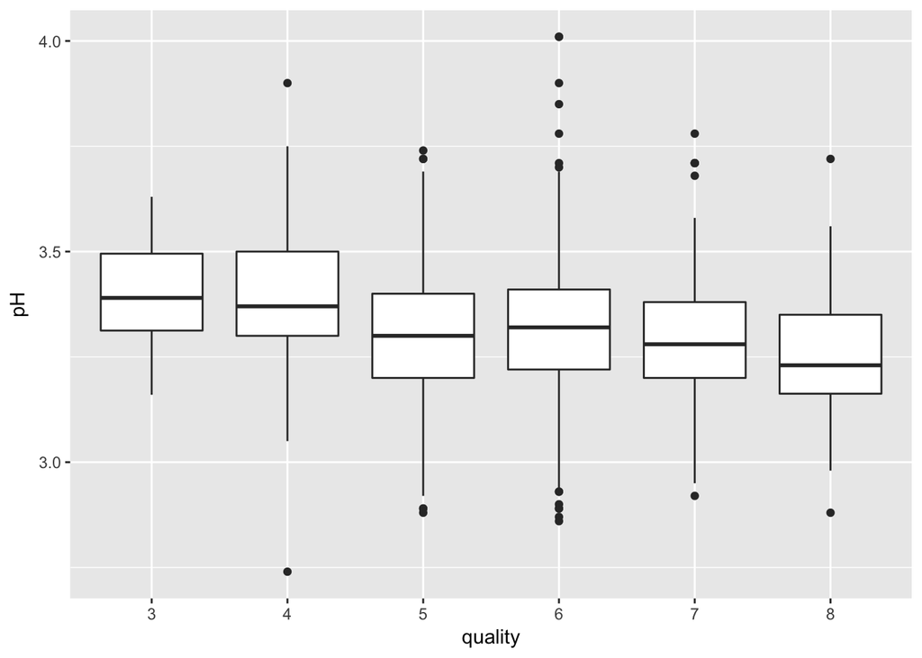

```r
library(hexbin)

wines %>%
  ggplot(mapping = aes(x = quality, y = pH))+
  geom_boxplot()
```

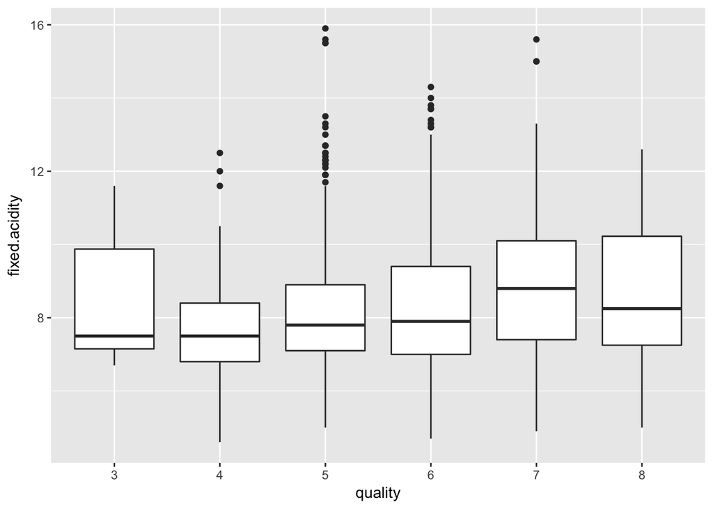

```r
wines %>%
  ggplot(mapping = aes(x = quality, y = fixed.acidity))+
  geom_boxplot()
```

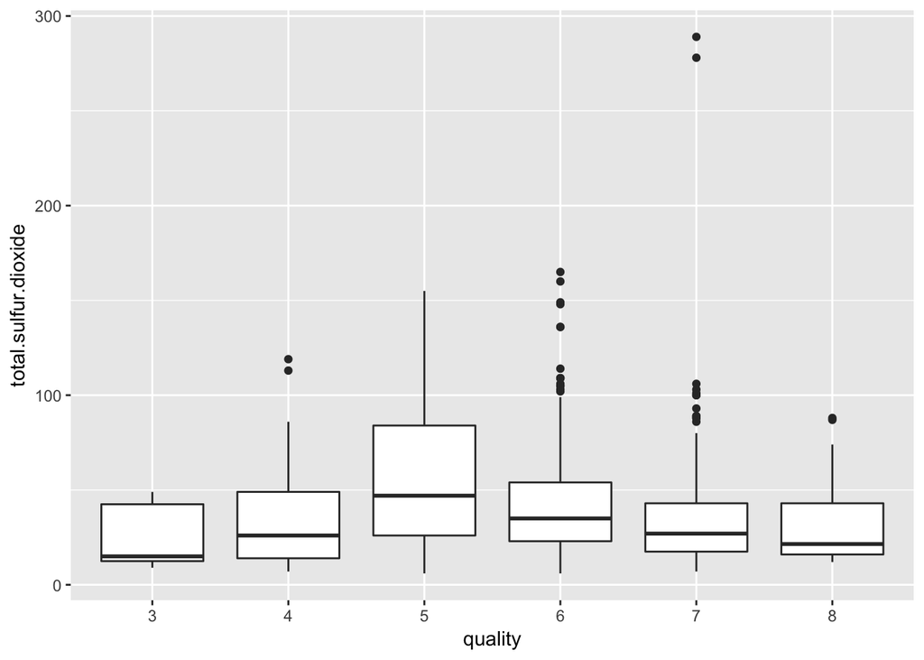

```r
wines %>%
  ggplot(mapping = aes(x = quality, y = total.sulfur.dioxide))+
  geom_boxplot()
```

[figure not shown]

```r
wines %>%
  ggplot(mapping = aes(x = quality, y = sulphates))+
  xlab("Notas")+
  ylab("Densidade")+
  geom_boxplot()
```

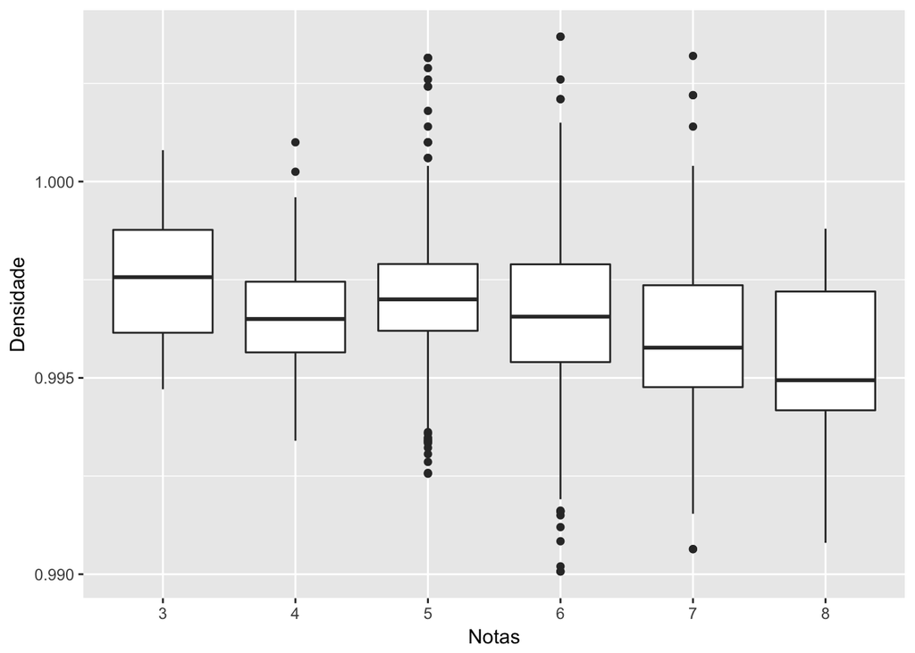

```r
wines %>%
  ggplot(mapping = aes(x = quality, y = density))+
  xlab("Notas")+
  ylab("Densidade")+
  geom_boxplot()
```

[figure not shown]

```r
wines %>%
  ggplot(mapping = aes(x = quality, y = wines$chlorides))+
  xlab("Notas")+
  ylab("Densidade")+
  geom_boxplot()
```

[figure not shown]

```r
wines %>%
  ggplot(mapping = aes(x = quality, y = wines$volatile.acidity))+
  xlab("Notas")+
  ylab("Densidade")+
  geom_boxplot()
```

[figure not shown]

```r
wines %>%
  ggplot(mapping = aes(x = quality, y = wines$citric.acid))+
  xlab("Notas")+
  ylab("Densidade")+
  geom_boxplot()
```

[figure not shown]

```r
wines %>%
  ggplot(mapping = aes(x = quality, y = wines$alcohol))+
  geom_point(aes(quality, pH))+
  xlab("Notas")+
  ylab("Densidade")+
  geom_boxplot()
```